# ChainLadder

## Agenda

- The ChainLadder package
- The Triangle Class
- Models available in ChainLadder
- Other Topics

## What is this 'ChainLadder'?

The `ChainLadder` package provides various statistical methods which are typically used for the estimation of outstanding claims reserves in general insurance, including those to estimate the claims development results as required under Solvency II.

```r
library(ChainLadder)
citation('ChainLadder')$textVersion
```

[1] "Markus Gesmann, Daniel Murphy, Yanwei (Wayne) Zhang, Alessandro Carrato, Giuseppe Crupi, Mario Wuthrich and Fabio Concina (2015). ChainLadder: Statistical Methods and Models for Claims Reserving in General. R package version 0.2.2. https://CRAN.R-project.org/package=ChainLadder"

## What is this 'ChainLadder'?

Authors:

- [Markus Gesmann](http://www.magesblog.com/)
- [Dan Murphy, FCAS, MAAA](http://trinostics.blogspot.com/)
- [Yanwei (Wayne) Zhang, FCAS](https://www.linkedin.com/in/yanwei-wayne-zhang-314597ab)
- [Alessandro Carrato, FIA](https://www.linkedin.com/in/alessandrocarrato)
- [Fabio Concina](https://www.linkedin.com/in/fabioconcina)
- [Prof. Dr. Mario V. Wüthrich](https://people.math.ethz.ch/~wueth/)

Github site:

- https://github.com/mages/ChainLadder

## The Triangle Class

Functions to ease the work with triangle shaped matrix data. A 'triangle' is a matrix with some generic functions. Triangles are usually stored in a 'long' format in data bases. The function `as.triangle` can transform a data.frame into a triangle shape.

```r
head(GenInsLong)
```

```
##   accyear devyear incurred claims
## 1       1       1          357848
## 2       2       1          352118
## 3       3       1          290507
## 4       4       1          310608
## 5       5       1          443160
## 6       6       1          396132
```

## The Triangle Class

```r
class(GenInsLong)
```

```
## [1] "data.frame"
```

```r
gen_ins_tri <- as.triangle(Triangle = GenInsLong, origin = "accyear", dev = "devyear",
  value = "incurred claims")
class(gen_ins_tri)
```

```
## [1] "triangle" "matrix"
```

## The Triangle Class

```r
str(gen_ins_tri)
```

```
##  triangle [1:10, 1:10] 357848 352118 290507 310608 443160 ...
##  - attr(*, "dimnames")=List of 2
##   ..$ accyear: chr [1:10] "1" "2" "3" "4" ...
##   ..$ devyear: chr [1:10] "1" "2" "3" "4" ...
##  - attr(*, "class")= chr [1:2] "triangle" "matrix"
```

## The Triangle Class

```r
gen_ins_tri[,1:8]
```

```
##        devyear
## accyear      1       2       3       4       5       6       7       8
##      1  357848 1124788 1735330 2218270 2745596 3319994 3466336 3606286
##      2  352118 1236139 2170033 3353322 3799067 4120063 4647867 4914039
##      3  290507 1292306 2218525 3235179 3985995 4132918 4628910 4909315
##      4  310608 1418858 2195047 3757447 4029929 4381982 4588268      NA
##      5  443160 1136350 2128333 2897821 3402672 3873311      NA      NA
##      6  396132 1333217 2180715 2985752 3691712      NA      NA      NA
##      7  440832 1288463 2419861 3483130      NA      NA      NA      NA
##      8  359480 1421128 2864498      NA      NA      NA      NA      NA
##      9  376686 1363294      NA      NA      NA      NA      NA      NA
##      10 344014      NA      NA      NA      NA      NA      NA      NA
```

## Exercise 1

1. Load the `ChainLadder` and `raw` packages
2. For the `NJM_WC` dataset:
   - Create an `R` object with class `triangle` and `matrix` with the incurred loss data
   - Remove all records with `DevelopmentYear` greater than 1997

     Extra Credit
   - Create an `R` object with class `data.frame` or `tbl_df` with the observed development factors for further examination
   - Using plotting (i.e. data visualization) tools only, identify the accident year that results in the largest 2:3 development factor.

## Exercise 1

```r
library(ChainLadder)
library(raw)
library(magrittr)
library(tibble)
library(tidyr)
library(dplyr)
library(ggplot2)

class(NJM_WC)
```

```
## [1] "tbl_df"     "tbl"        "data.frame"
```

## Exercise 1

```r
njm_wc_tri <- NJM_WC %>%
  dplyr::filter(DevelopmentYear <= 1997)
class(njm_wc_tri)
```

```
## [1] "tbl_df"     "tbl"        "data.frame"
```

## Exercise 1

```r
njm_wc_tri <- as.triangle(Triangle = njm_wc_tri, origin = 'AccidentYear',
  dev = 'Lag', value =  'CumulativeIncurred'); njm_wc_tri[,1:8]
```

```
##             Lag
## AccidentYear      1      2      3      4      5      6      7      8
##         1988 167087 166976 166458 170327 178065 179126 175786 176194
##         1989 179470 185511 190758 202576 204649 201686 202141 204552
##         1990 198993 215685 226829 228487 225776 226678 228830 228252
##         1991 237457 245174 247201 247388 245651 249402 251541     NA
##         1992 256936 272664 272226 266570 263346 263655     NA     NA
##         1993 273382 273792 266742 259781 261032     NA     NA     NA
##         1994 311979 290504 264756 263642     NA     NA     NA     NA
##         1995 288726 265868 255992     NA     NA     NA     NA     NA
##         1996 258617 236631     NA     NA     NA     NA     NA     NA
##         1997 216437     NA     NA     NA     NA     NA     NA     NA
```

## Exercise 1

```r
class(njm_wc_tri)
```

```
## [1] "triangle" "matrix"
```

```r
dim(njm_wc_tri)
```

```
## [1] 10 10
```

```r
njm_wc_df <- njm_wc_tri[,2:10] / njm_wc_tri[,1:9] %>%
  as_tibble()
njm_wc_df <- dplyr::mutate(njm_wc_df, accident_year = as.character(1988:1997))
names(njm_wc_df)[1:9] <- paste(1:9, "to", 2:10)
```

## Exercise 1

```r
njm_wc_df <- gather(njm_wc_df, key = interval, value = development_factor, 1:9,
  na.rm = TRUE)

head(njm_wc_df)
```

```
##   accident_year interval development_factor
## 1          1988   1 to 2          0.9993357
## 2          1989   1 to 2          1.0336602
## 3          1990   1 to 2          1.0838823
## 4          1991   1 to 2          1.0324985
## 5          1992   1 to 2          1.0612137
## 6          1993   1 to 2          1.0014997
```

## Exercise 1

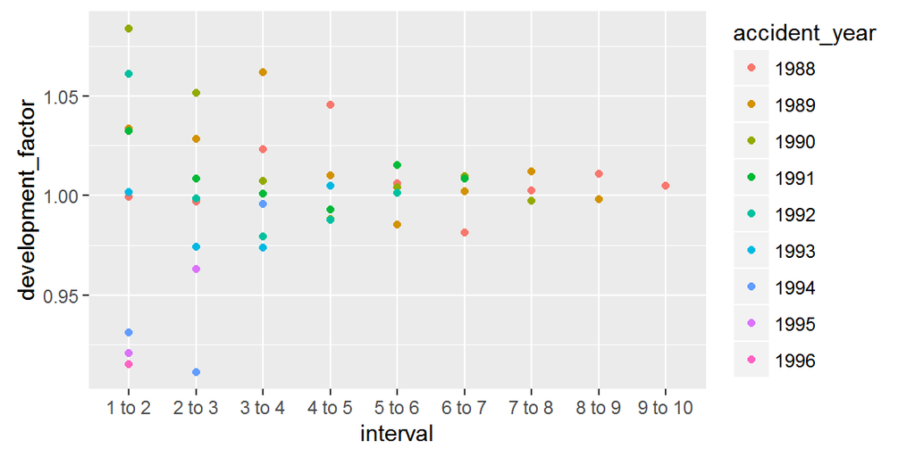

```r
ggplot(data = njm_wc_df, mapping = aes(x = interval, y = development_factor,
  color = accident_year)) + geom_point()
```

## Actuarial Projection Models

Models Available in `ChainLadder`:

- `BootChainLadder` (`CDR`)
- `ClarkCapeCod`
- `ClarkLDF`
- `glmReserve`
- `MackChainLadder` (`CDR`)
- `tweedieReserve`
- `MultiChainLadder` (Join2Fits)
- `MunichChainLadder` (Requires Paid and Incurred)
- `PaidIncurredChain` (Requires Paid and Incurred)

## How do I use these models?

1. Read the help function
   - Understand the arguments
2. Apply the function and assign the result to an object
3. Understand the output
   - `str`
   - `summary`
   - `plot`
4. Extract what you need
   - S3 class `[`
   - S4 class `$`

## BootChainLadder

`BootChainLadder(Triangle, R = 999, process.distr=c("gamma", "od.pois"))`

- The BootChainLadder procedure provides a predictive distribution of reserves or IBNRs for a cumulative claims development triangle.
- `process.distr` - character string indicating which process distribution to be assumed. One of "gamma" (default), or "od.pois" (over-dispersed Poisson), can be abbreviated
- *England, PD and Verrall, RJ. Stochastic Claims Reserving in General Insurance (with discussion)*, British Actuarial Journal *8, III. 2002*

## Excercise 2

Run the following code to create a paid triangle for other liability:

```r
liab_tri <- as.triangle(Triangle =
    othliab[othliab$GRNAME == 'State Farm Mut Grp' &
        othliab$DevelopmentYear <= 1997, ],
  origin = 'AccidentYear', dev = 'DevelopmentLag', value = 'CumPaidLoss_h1')
```

## Excercise 2

For the ClarkLDF method estimate with a tail that is:

1. 20 years in length
2. measured from the beginning of the accident year
3. modeled using a loglogistic growth curve

## Excercise 2

Provide the following:

1. Total 'IBNR' (Unpaid)
2. The indicated cumulative LDF for 1989 for the specified growth function (without regards to the selected length of the tail)
3. The LDF truncated to 20 years for 1989

   Extra Credit
4. The indicated cumulative development factor at age 15 (with and without truncation)

## Excercise 2

```r
clark <- ClarkLDF(Triangle = liab_tri, maxage = 20, adol = FALSE)
clark$Total$FutureValue
```

```
## [1] 1141360
```

```r
clark$Ldf[2]
```

```
## [1] 1.044781
```

```r
clark$TruncatedLdf[2]
```

```
## [1] 1.040017
```

## Excercise 2

```r
unname(1 + (clark$THETAG[2]/15)^clark$THETAG[1])
```

```
## [1] 1.010415
```

```r
unname(1 + (clark$THETAG[2]/15)^clark$THETAG[1] /
    1 + (clark$THETAG[2]/20)^clark$THETAG[1])
```

```
## [1] 1.014996
```

## Tails

Both the `ClarkCapeCod` and `ClarkLDF` fit growth functions to extrapolate the development pattern.

`tail ~ c("G", "maxage")`

See the Clark paper for the forms of the extrapolation model.

## Selected Loss Development Factors

The `CLFMdelta` function

```r
init_df <- MackChainLadder(Triangle = liab_tri)$f
sel_df <- init_df
sel_df[3] <- 1.5
alphas <- CLFMdelta(Triangle = liab_tri, selected = sel_df[1:9])
full_tri <- predict(chainladder(liab_tri, delta = alphas))
```

## Selected Loss Development Factors

```r
full_tri[7:10,1:5]
```

```
##       dev
## origin     1        2        3        4        5
##   1994  9720  65339.0 130303.0 186750.0 213678.7
##   1995  7171  82822.0 160302.0 240453.0 275125.5
##   1996 16696  88800.0 175128.2 262692.3 300571.6
##   1997 21098 161171.9 317857.5 476786.2 545537.1
```

```r
full_tri[,4] / full_tri[,3]
```

```
##     1988     1989     1990     1991     1992     1993     1994     1995
## 1.747868 1.397273 1.474309 1.410887 1.363125 1.308281 1.433198 1.500000
##     1996     1997
## 1.500000 1.500000
```

## Selected Loss Development Factors

This has the potential to support the variability calcaulation from the [CLFM paper](http://www.variancejournal.org/issues/06-02/143.pdf)

[Github issue](https://github.com/mages/ChainLadder/issues/23)

## Quarterly Triangles

The `qpaid` and `qincurred` are included in ChainLadder to demonstrate how to deal with triangles with quarterly evlautions and annual periods.

```r
# ?qpaid #not run
dim(qpaid)
```

```
## [1] 12 45
```

```r
## MackChainLadder expects a quadratic matrix so let's expand
## the triangle to a quarterly origin period.
n <- ncol(qpaid) # Number of quarterly valuations
Paid <- matrix(NA, n, n) # create a matrix with NAs
Paid[seq(from = 1, to = n, by = 4),] <- qpaid # fill in every 4th row with the annual data
```

## Questions??

Rajesh Sahasrabuddhe 215 246 1028 Write me!